# 5-2. Correlation Matrix

### 10. Use `chart.Correlation{PerformanceAnalytics}` : Draw scatter plots

The function `chart.Correlation{PerformanceAnalytics}`, can be used to display a chart of a correlation matrix.

- Install PerformanceAnalytics :

```r
install.packages("PerformanceAnalytics", quiet = TRUE)
```

- Use `chart.Correlation{PerformanceAnalytics}` :

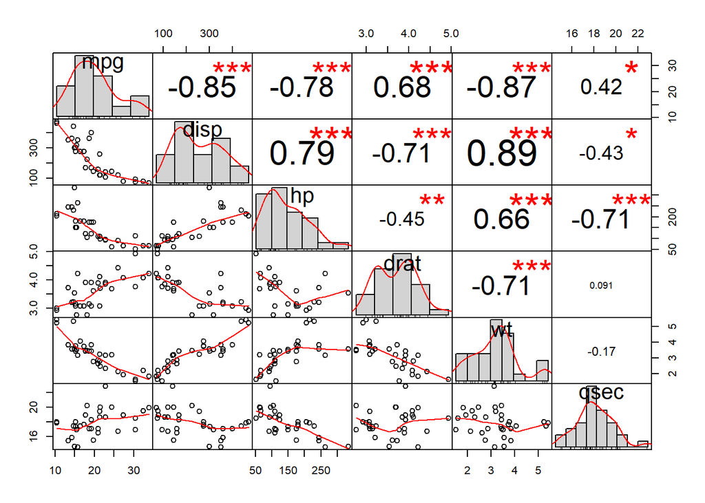

```r
library("PerformanceAnalytics", quietly = TRUE)

my_data <- mtcars[, c(1,3,4,5,6,7)]
chart.Correlation(my_data, histogram=TRUE, pch=19)
```

- In the above plot:
  - The distribution of each variable is shown on the diagonal.
  - On the bottom of the diagonal : the bivariate scatter plots with a fitted line are displayed
  - On the top of the diagonal : the value of the correlation plus the significance level as stars
  - Each significance level is associated to a symbol : p-values(0, 0.001, 0.01, 0.05, 0.1, 1) to symbols(***, **, *, ., ’ ’)

### 11. Use `heatmap{stats}`

- `x` : the correlation matrix to be plotted
- `col` : color palettes
- `symm` : logical indicating if x should be treated symmetrically; can only be true when x is a square matrix.

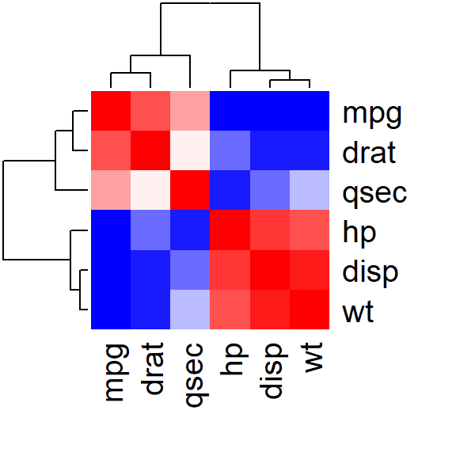

```r
# Get some colors

# colorRampPalette{grDevices} : Color interpolation
#   These functions return functions that interpolate a set of given colors
#   to create new color palettes (like topo.colors) and color ramps,
#   functions that map the interval [0, 1] to colors
col<- colorRampPalette( c("blue", "white", "red") )(20)

# heatmap{stats} : draw a Heat Map
#   symm : logical indicating if x should be treated symmetrically;
#          can only be true when x is a square matrix.
heatmap(x = res, col = col, symm = TRUE)
```